# Practical 5 Report

Jakub Domasik

## Introduction

In this report, we will examine how relationships between valence and danceability differ for songs containing speech. Therefore, libraries *splines* and *ggplot2* are required. We will investigate this relationship on the *edited_spotify.xlsx* dataset for variables: *TrackValence*, *TrackDanceability* and *TrackSpeechiness*.

## Analysis

To further investigate this difference, three models will be constructed. The first one is a simple linear model of the dependance between *TrackDanceability* and *TrackValence*. The second one allows the intercept to be different for speechy and non-speechy tracks. In the last model, all parameters may be different for rap and non-rap songs.

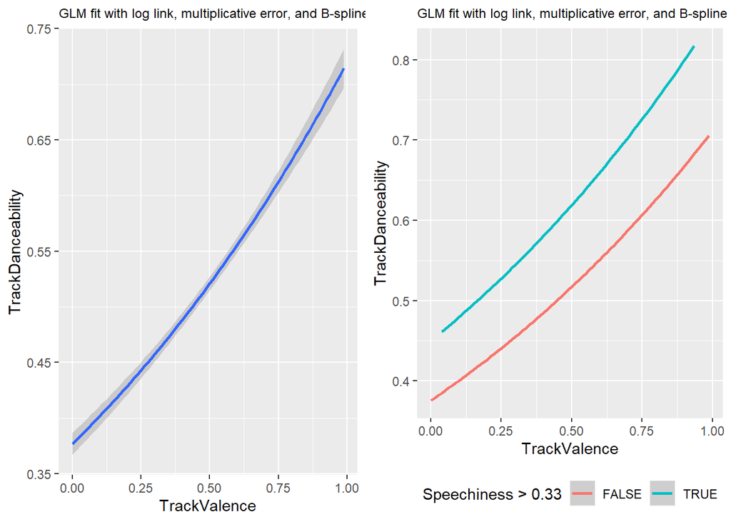

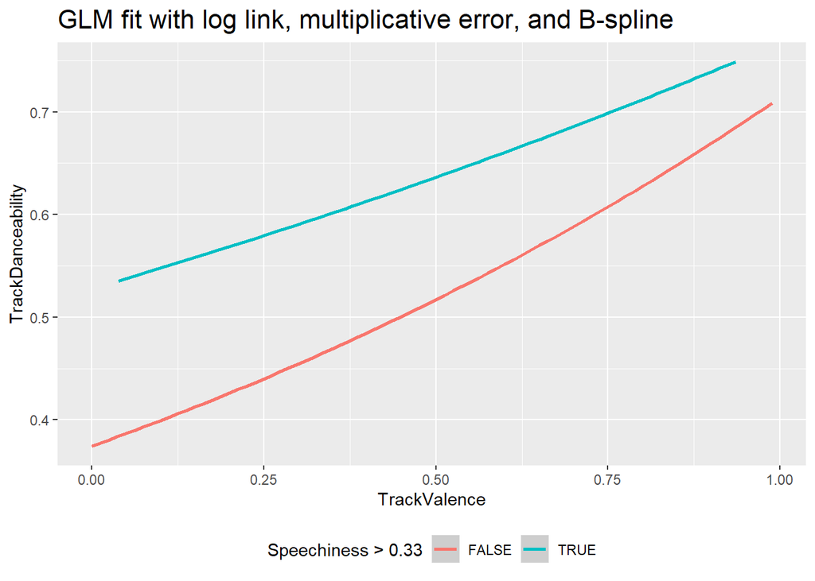

In the first graph, we see a very high correlation between valance of the track and its danceability. The fit looks more or less as a straight line with a slight bend in the middle facing downwards. From the second model, we learn that rap albums have a larger intercept which means that on average they have larger danceability score by around 0.08. Last plot shows us that the line representing non-rap songs have much smaller intercept(by around 0.15), however it has a much steeper slope so non-rap songs which are very valent have similar danceability as rap songs with high valence. We may say that the difference in danceability between rap and non-rap songs is diminishing as the valence of the tracks is growing.

Next, I will try to cluster the albums based on three variables: *TrackValence*, *AlbumSpeechiness* and *AlbumDanceability*. We have 211 rows and it is reasonable to define 8 clusters, because people usually define 8 main genres of music.

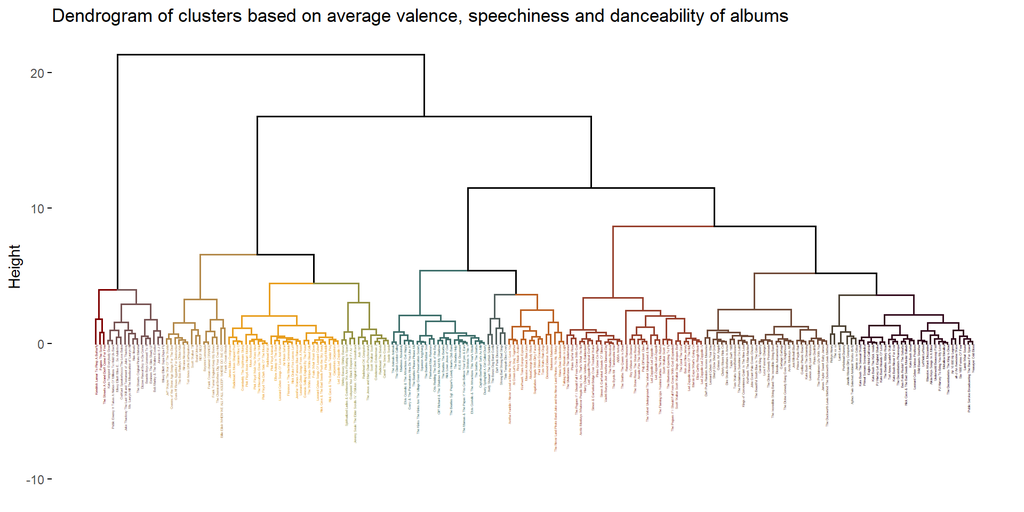